# Sheet 5 Exercise 3: Nonlinear Neural Field (Credits: 4)

Note: All analytical computations are supposed to be carried out by hand! You need to submit your computations to complete the exercise. You can either write your computations into the notebook using LaTeX syntax, or submit them on paper (scan).

Consider a nonlinear neural field of Amari type with the step threshold function. The model is given by the equation $$ \tau\dot{u}(x,t) = -u(x,t) + \int_{-\infty}^{\infty} w(x-x^\prime)1(u(x^\prime,t))\text{d}x^\prime + s(x,t) + h. $$

Assume that the resting potential is given by $h=-1$. The input $s$ and the interaction kernel $w$ are given by piecewise-linear functions, namely $$ s(x) := \begin{cases} C\left( 1-\frac{\vert x\vert}{d} \right), & \vert x\vert \leq d \\ 0, & \text{elsewhere}, \end{cases} $$ and $$ w(x) := \begin{cases} r, & \vert x\vert < a \\ -s, & a\leq\vert x\vert\leq b \\ 0, & \text{elsewhere}. \end{cases} $$

#### 3.1

Simulate the equation to approximately find the time-dependent solution of the model. You can do this exactly as in Exercise 2 using the Euler method and a Riemann-sum-approximation of the integral. Use the parameters $\tau=1$, $r=3$, $s=1.75$, $C=0.6$, $a=1$, $b=3$, $d=4$ and $h=-1$. For the spatial domain, use $A=-20$, $B=20$ as the integral borders.

First, start the model at resting level (i.e. $u(x,0) = h$). Then use the initial condition $u(x,0) = 3.3 s(x) + h$. Finally, use the interaction kernel $\hat{w}(x) := 0.1 w(x)$ and the initial condition $u(x,0) = 3.3 s(x) + h$.

Create 3D plots of the three time-dependent solutions. What do you oberserve about the stationary solutions, and the evolution towards them? Can you explain the results?

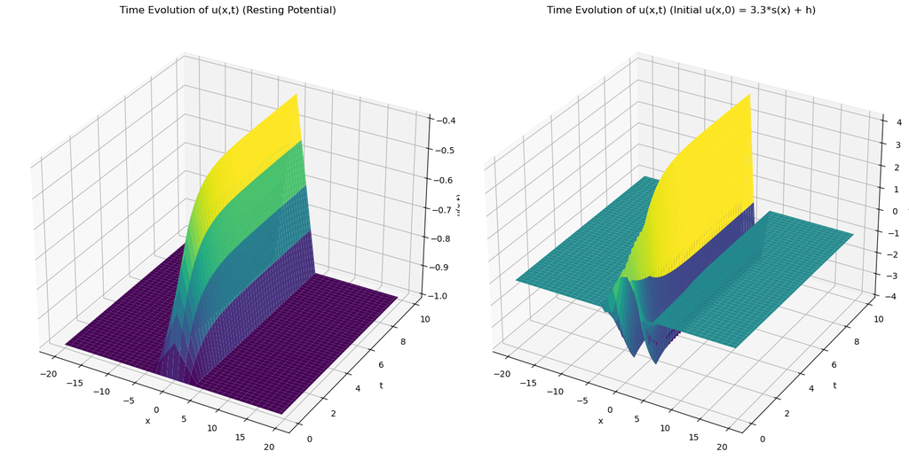

```python
import numpy as np
import matplotlib.pyplot as plt
from mpl_toolkits.mplot3d import Axes3D

# Define parameters
tau = 1
r = 3
s_val = 1.75
C = 0.6
a = 1
b = 3
d = 4
h = -1
x_min, x_max = -20, 20
dx = 0.5  # Space step
dt = 0.1  # Time step
T_max = 10  # Max time
x_vals = np.arange(x_min, x_max, dx)  # Spatial grid
num_x = len(x_vals)
time_steps = int(T_max / dt)  # Number of time steps

# Define the input s(x)
def s(x):
    return np.where(np.abs(x) <= d, C * (1 - np.abs(x) / d), 0)

# Define the interaction kernel w(x)
def w(x):
    return np.where(np.abs(x) < a, r, np.where((np.abs(x) >= a) & (np.abs(x) <= b), -s_val, 0))

# Define the step function 1(u)
def step(u):
    return np.where(u > 0, 1, 0)

# Initialize u(x, 0) = h (resting potential) and u(x, 0) = 3.3 * s(x) + h
u_0 = np.full(num_x, h)  # Resting potential initial condition
u_1 = 3.3 * s(x_vals) + h  # Modified initial condition with s(x)

# Function to update u(x,t) using Euler method
def update_u(u, t):
    new_u = np.copy(u)
    for i, x in enumerate(x_vals):
        integral_term = 0
        for j, x_prime in enumerate(x_vals):
            integral_term += w(x - x_prime) * step(u[j]) * dx  # Approximation of the integral
        new_u[i] = u[i] + dt * (-u[i] + integral_term + s(x_vals[i]) + h)  # Euler update rule
    return new_u

# Simulate the system for three initial conditions
u_rest = np.copy(u_0)
u_s = np.copy(u_1)

# Time evolution for u_rest (h = -1, initial condition 1)
u_t_rest = np.zeros((time_steps, num_x))
u_t_rest[0] = u_rest
for t in range(1, time_steps):
    u_t_rest[t] = update_u(u_t_rest[t-1], t)

# Time evolution for u_s (h = -1, initial condition 2)
u_t_s = np.zeros((time_steps, num_x))
u_t_s[0] = u_s
for t in range(1, time_steps):
    u_t_s[t] = update_u(u_t_s[t-1], t)

# Plotting 3D plots for both cases
fig = plt.figure(figsize=(15, 10))

# Plot u(x,t) for resting condition (initial u(x, 0) = h)
ax1 = fig.add_subplot(121, projection='3d')
X, T = np.meshgrid(x_vals, np.arange(time_steps) * dt)
ax1.plot_surface(X, T, u_t_rest, cmap='viridis')
ax1.set_title('Time Evolution of u(x,t) (Resting Potential)')
ax1.set_xlabel('x')
ax1.set_ylabel('t')
ax1.set_zlabel('u(x,t)')

# Plot u(x,t) for the second condition (initial u(x, 0) = 3.3 * s(x) + h)
ax2 = fig.add_subplot(122, projection='3d')
ax2.plot_surface(X, T, u_t_s, cmap='viridis')
ax2.set_title('Time Evolution of u(x,t) (Initial u(x,0) = 3.3*s(x) + h)')
ax2.set_xlabel('x')
ax2.set_ylabel('t')
ax2.set_zlabel('u(x,t)')
plt.tight_layout()
plt.show()
```

[output not shown]

**Explanation:**

**Looking at the Stationary Solutions, I observe that:**

- The system reaches a stationary state where $u(x,t)$ no longer changes with time. This happens when the rate of change $\dot{u}(x,t)$ becomes zero, i.e., the inputs and interactions balance out.
- Initially, $u(x,t)$ evolves rapidly, but as time progresses, the system stabilizes to a steady state.
- The system with initial condition $u(x, 0) = h$ reaches a stationary state slower, while the system starting with $ u(x, 0) = 3.3 \cdot s(x) + h$ stabilizes faster due to the larger initial deviation.

**This could be explained by:**

- The stationary solutions represent the long-term equilibrium of the system.
- The system self-organizes through local interactions and inputs, eventually reaching a steady-state configuration.

#### 3.2

Analytically compute the stationary solution for the case in which there is no excited region in the field. Why does no peak arise here? What is the treshold value for the input amplitude $C$ that is needed for an activated region to emerge?

**Explanation:**

**PLEASE SEE THE SUBMITED PDF**

#### 3.3

Consider again the first interaction kernel $w$ and the initial condition $u(x,0) = 3.3 s(x) + h$. Now set the input signal to zero (but not the initial condition!). Simulate the model. Which stationary solution emerges? How do you explain the result?

```
Maximum value of u(x,t) at equilibrium: 3.4998635552829294
Position where maximum occurs: 0.0
```

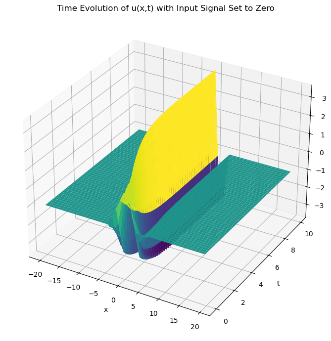

```python
# Set the input signal to zero
def s_zero(x):
    return np.zeros_like(x)  # The input signal is now zero everywhere

# Set the initial condition u(x, 0) = 3.3 * s(x) + h
u_zero_input = 3.3 * s(x_vals) + h  # Using the initial condition with input signal

# Simulate the system with input signal set to zero
u_t_zero_input = np.zeros((time_steps, num_x))
u_t_zero_input[0] = u_zero_input

# Function to update u(x,t) using Euler method when s(x) = 0
def update_u_zero_input(u, t):
    new_u = np.copy(u)
    for i, x in enumerate(x_vals):
        integral_term = 0
        for j, x_prime in enumerate(x_vals):
            integral_term += w(x - x_prime) * step(u[j]) * dx  # Approximation of the integral
        new_u[i] = u[i] + dt * (-u[i] + integral_term + s_zero(x_vals[i]) + h)  # Euler update rule
    return new_u

# Run the simulation with the input signal zero
for t in range(1, time_steps):
    u_t_zero_input[t] = update_u_zero_input(u_t_zero_input[t-1], t)

# Extract the final time step to find the equilibrium values
final_u = u_t_zero_input[-1]
# Find the maximum value of u(x,t) at equilibrium
max_u_value = np.max(final_u)
# Find the position (x) at which the maximum value occurs
max_u_position = x_vals[np.argmax(final_u)]

# Output the maximum value and its position
print(f"Maximum value of u(x,t) at equilibrium: {max_u_value}")
print(f"Position where maximum occurs: {max_u_position}")
# Plotting the time evolution of u(x,t) with the input signal set to zero
#  3D plot of the time evolution
fig = plt.figure(figsize=(10, 7))

ax = fig.add_subplot(111, projection='3d')
X, T = np.meshgrid(x_vals, np.arange(time_steps) * dt)
ax.plot_surface(X, T, u_t_zero_input, cmap='viridis')
ax.set_title('Time Evolution of u(x,t) with Input Signal Set to Zero')
ax.set_xlabel('x')
ax.set_ylabel('t')
ax.set_zlabel('u(x,t)')
plt.tight_layout()
plt.show()
```

#### 3.4 (Non-mandatory)

In the situation of 3.3, analytically compute the exact size of the stable peak.

*Hint:* Use the theorems found by Amari (1977). You can check your results using the plot from 3.3.